# Homework 5

Haicheng Xu, James Bentley Math 189 Spring 2023

## Conceptual Question

1. Why do we need to check modeling assumptions for linear regression?

Modeling assumptions are required for linear regression because if the true relationship is not a linear relationship, the model will not be accurate.

## Application Question

2. Plot bmi versus charges. Comment on any relationship you see.

```r
insurance = read.csv("insurance.csv")
head(insurance)
```

```
##   age    sex    bmi children smoker    region   charges
## 1  19 female 27.900        0    yes southwest 16884.924
## 2  18   male 33.770        1     no southeast  1725.552
## 3  28   male 33.000        3     no southeast  4449.462
## 4  33   male 22.705        0     no northwest 21984.471
## 5  32   male 28.880        0     no northwest  3866.855
## 6  31 female 25.740        0     no southeast  3756.622
```

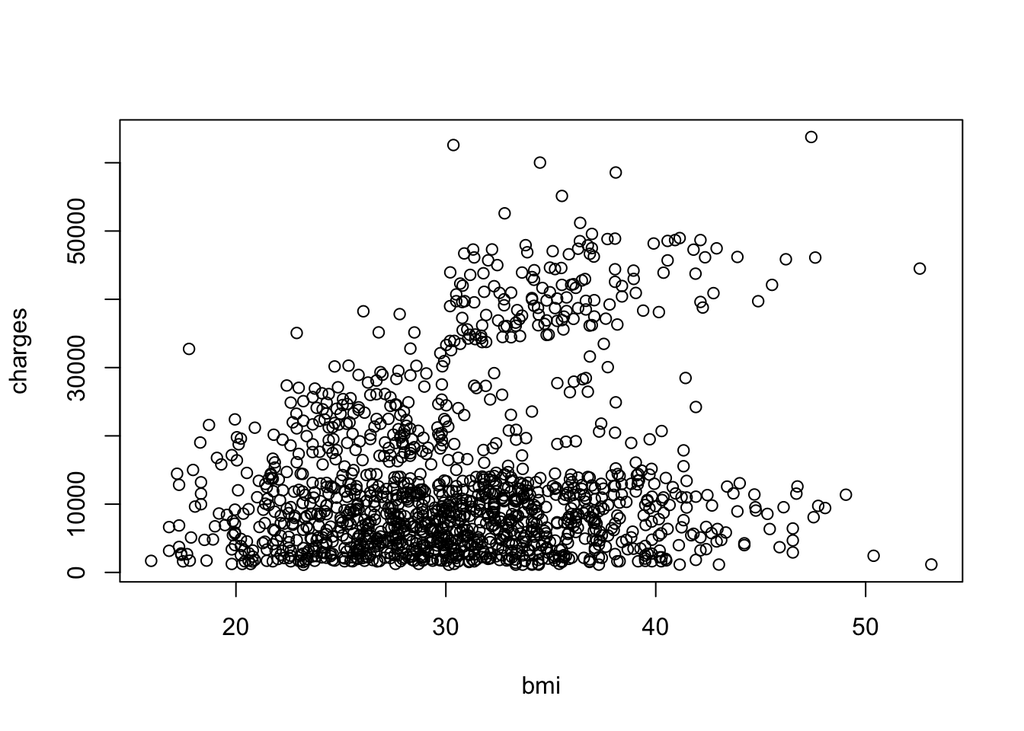

```r
with(insurance,plot(bmi,charges))
```

There appears to be a weak positive correlation between bmi and charges. This is likely because individuals with higher bmi’s are more likely to experience health problems.

3. Make side-by-side box plots of charges for smokers and non-smokers. Does it appear that smoker’s have higher medical bills?

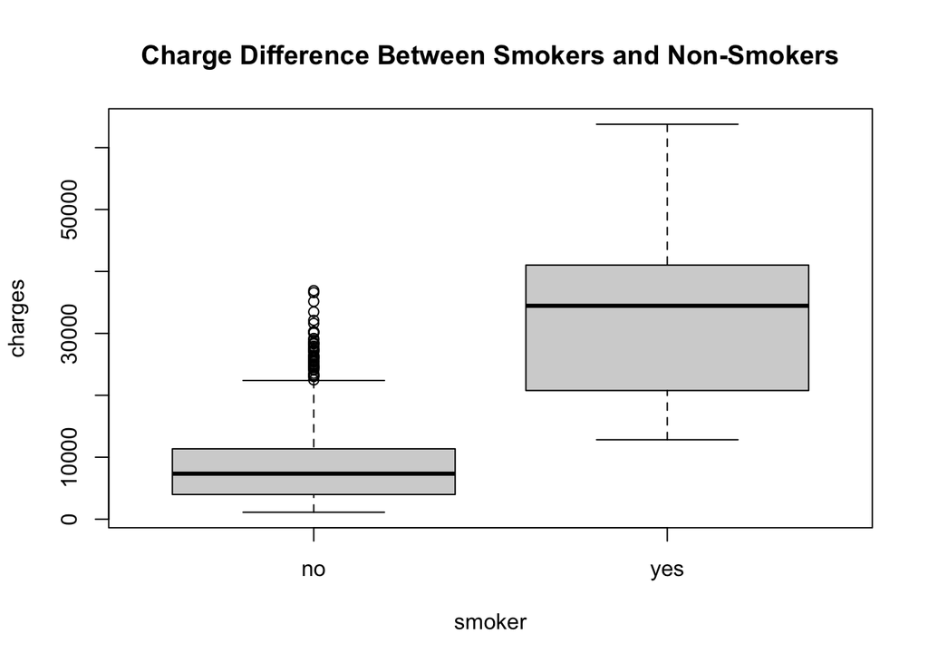

```r
boxplot(charges~smoker,data=insurance,main="Charge Difference Between Smokers and Non-Smokers")
```

Yes, smokers appear to have a significantly higher insurance charges compared to non-smokers. In this case, smokers seem to have a median charge of around $35,000 versus non-smokers around $7500. The 25 percentile charge of smokers is higher than the 75 percentile of non-smokers.

4. Fit a linear model with charges as the response and bmi, and smoker as explanatory variables.

```r
lm.fit <- lm(charges ~ bmi + smoker, data = insurance)
```

1. Return the summary of your fitted model.

```r
summary(lm.fit)
```

```
##
## Call:
## lm(formula = charges ~ bmi + smoker, data = insurance)
##
## Residuals:
##      Min       1Q   Median       3Q      Max
## -15992.7  -4600.2   -802.4   3636.2  30677.8
##
## Coefficients:
##             Estimate Std. Error t value Pr(>|t|)
## (Intercept) -3459.10     998.28  -3.465 0.000547 ***
## bmi           388.02      31.79  12.207  < 2e-16 ***
## smokeryes   23593.98     480.18  49.136  < 2e-16 ***
## ---
## Signif. codes:  0 '***' 0.001 '**' 0.01 '*' 0.05 '.' 0.1 ' ' 1
##
## Residual standard error: 7088 on 1335 degrees of freedom
## Multiple R-squared:  0.6579, Adjusted R-squared:  0.6574
## F-statistic:  1284 on 2 and 1335 DF,  p-value: < 2.2e-16
```

2. Provide an interpretation of the coefficient for smoker in your fitted model in the context of the problem.

The coefficient on smoker is 23,593.98, meaning that the average smoker gets billed $23,593.98 by health insurance more than non-smokers in this dataset.

3. Provide an interpretation of the coefficient for bmi in your fitted model in the context of the problem.

The coefficient for bmi is 388.02, which means that for every unit increase in bmi level results in a $388.02 increase in charges.

4. Plot the model residuals against the model predicted values. Do you see any violations of linear model assumptions?

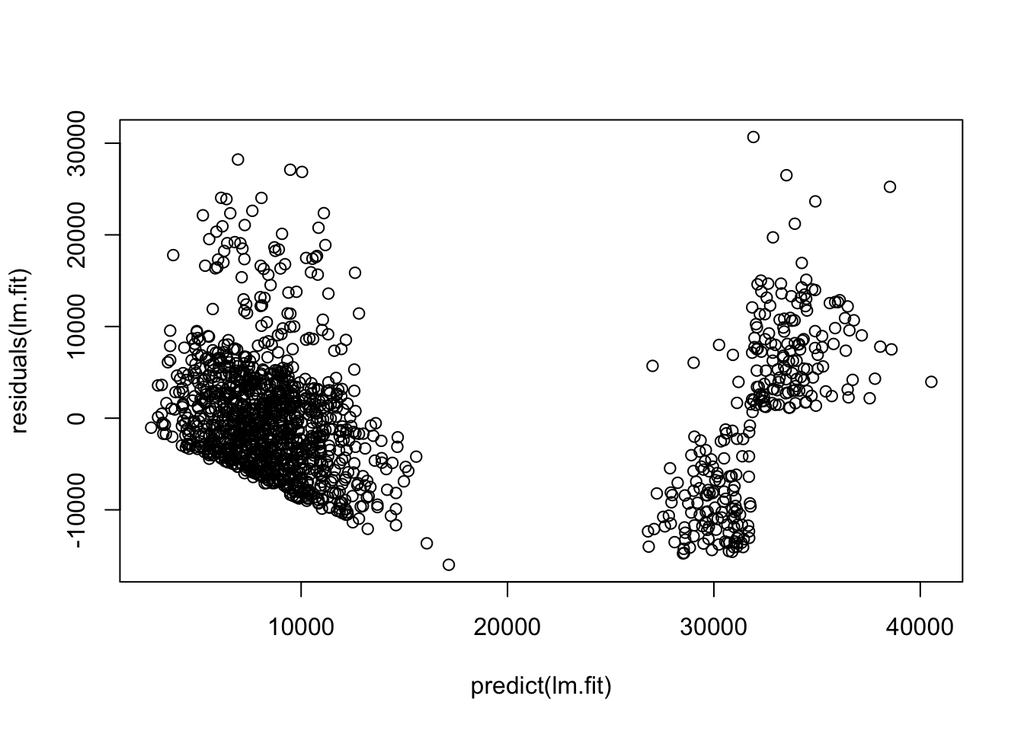

```r
plot(predict(lm.fit), residuals(lm.fit))
```

There is a violation in the homoscedasticity of the data. There is more variance in the prediction error for smokers compared to non-smokers.

5. Check whether the assumption of Normality of residuals holds. Include any relevant plots you used to make your assessment.

There’s a violation in Normality assumption since the right tail of the normal quantile plot is not resting on the line. Additionally, the residuals plot above shows a right skewed residuals: positive residuals goes to upwards of 30000, while the negative residuals are all greater than -20000.

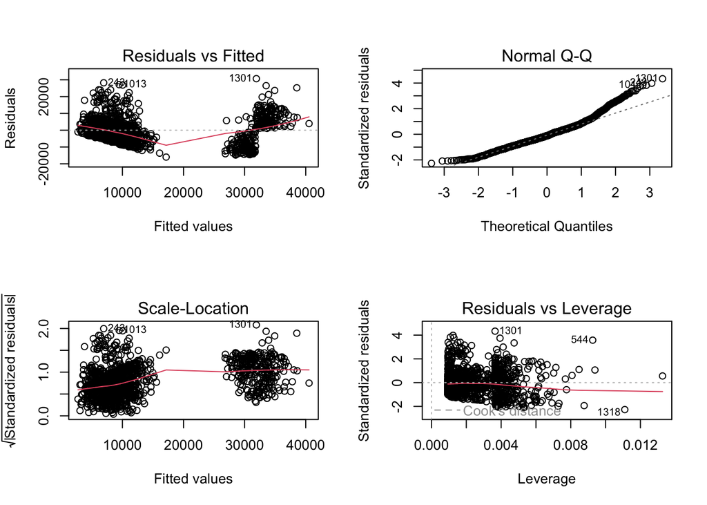

```r
par(mfrow = c(2, 2))
plot(lm.fit)
```

5. Fit the same linear model, except this time use log(charges).
1. Return the summary of your fitted model.

```r
lm.fit <- lm(log(charges) ~ bmi + smoker, data = insurance)
summary(lm.fit)
```

```
##
## Call:
## lm(formula = log(charges) ~ bmi + smoker, data = insurance)
##
## Residuals:
##      Min       1Q   Median       3Q      Max
## -2.17030 -0.40754  0.09871  0.44368  1.75504
##
## Coefficients:
##             Estimate Std. Error t value Pr(>|t|)
## (Intercept) 8.186576   0.095254  85.945  < 2e-16 ***
## bmi         0.019629   0.003033   6.472 1.36e-10 ***
## smokeryes   1.514765   0.045818  33.061  < 2e-16 ***
## ---
## Signif. codes:  0 '***' 0.001 '**' 0.01 '*' 0.05 '.' 0.1 ' ' 1
##
## Residual standard error: 0.6763 on 1335 degrees of freedom
## Multiple R-squared:  0.4598, Adjusted R-squared:  0.459
## F-statistic: 568.3 on 2 and 1335 DF,  p-value: < 2.2e-16
```

3. Check whether the assumption of Normality of residuals holds. Include any relevant plots you used to make your assessment.

As shown in the residual plots below, the log transformation of charges fixed the normality problem: the residuals are now roughly normally distributed.

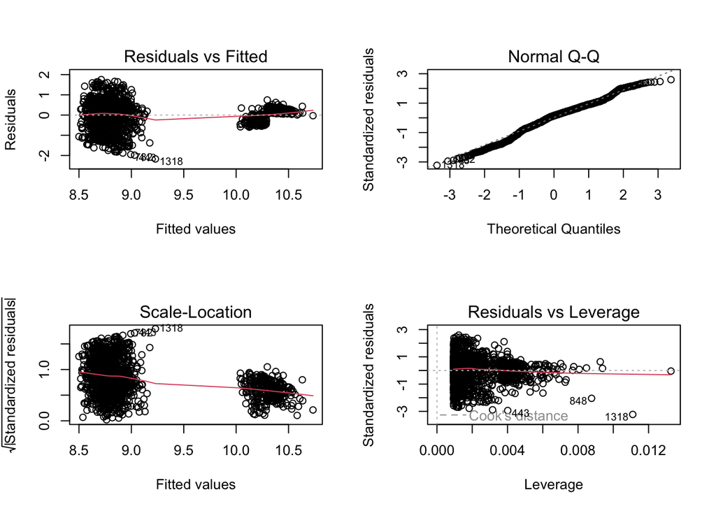

```r
par(mfrow = c(2, 2))
plot(lm.fit)
```

4. Comment on differences between the model you fit in (4) versus the model you fit in (5).

We fitted the the model using charge in part four, while we fitted the same model except we log transformed charges. This change makes our interpretation of the coefficients different: it changed from unit increase to percentage increase for the dependent variable (charges) when there’s a unit increase in the independent variables (bmi and smokers). This change also results in a difference in residual distribution, where the residuals of the transformed data is roughly normally distributed, which is not the case for the non-transformed data.

6. Consider the model you fit in problem (5).
1. Suppose we want to test whether bmi has a significant effect on predicted medical charges. Report the appropriate null and alternative hypotheses. Define any variables you use.

Null hypothesis: Bmi has no significant effect on predicted medical charges, so the coefficient of bmi is equal to 0.

Alternative hypothesis: Bmi has a significant effect on predicted medical charges, and the coefficient of bmi is not equal to 0.

We will use bmi and charges. Bmi is body mass index which is a measure of one’s body fat level. Charges is medical charges billed by health insurance.

We are performing a two tail t test with alpha = 0.05:

```r
coefficient = .19629
SE = .003033
test_statistic <- (coefficient - 0) / SE
test_statistic
```

[output not shown]

```r
critical_value <- 1.96
reject <- test_statistic > critical_value
reject
```

```
## [1] TRUE
```

3. Provide a 95% confidence interval for your estimated coefficient for bmi.

```r
bottom <- coefficient - 2 * SE
top <- coefficient + 2 * SE

bottom
```

[output not shown]

```r
top
```

[output not shown]

Haicheng and James collaborated on the entire assignments equally.